# ForestSearch Scenario Validation Suite

- Show All Code
- Hide All Code
- View Source

End-to-End Simulation Tests for All Search Configurations

Author

Larry F. León

Published

April 10, 2026

# 1 Purpose

This document validates **every combination** of search type (harm / benefit) $\times$ outcome orientation (adverse / positive) $\times$ endpoint type (binary / continuous / count / survival) through small-scale simulations — 16 scenarios total.

Each scenario plants a known subgroup Q = {z1 == 1 & z2 == 1} and confirms that ForestSearch:

1. **Detects Q** under H1 (detection rate > 50%)
2. **Controls FPR** under H0 (false positive rate < 15%)

## 1.1 Null DGM Design

The null hypothesis in ForestSearch is **no treatment effect heterogeneity** (no HTE). This does NOT mean zero treatment effect. Under H0, everyone receives a homogeneous (generally beneficial) treatment effect — there is no subgroup with a different treatment effect.

FPR depends on the **gap between the null ITT effect and the screening threshold**. When this gap is small, random sampling variability pushes some subgroup estimates above the threshold, inflating FPR. This is expected statistical behaviour, not a sign convention error.

For **benefit + adverse** and **harm + positive** scenarios with switched treatment, any non-zero beneficial treatment inverts on the search scale, moving the ITT closer to the threshold. These scenarios use `k_treat = 0` to zero out the treatment coefficient, isolating the sign convention test from the multiplicity issue. In practice, the $L_\text{eff}$ calibration procedure handles threshold selection for realistic ITT effects.

## 1.2 Implementation Details

The table below shows how each scenario maps to ForestSearch parameters. The **Null ITT** column always reports the effect of the **original treatment** on the **original outcome**.

**Interpretation of Null ITT values:**

- **Adverse outcomes** (events, pain, hazard): beneficial treatment produces OR/IRR/HR < 1 or MD < 0.
- **Positive outcomes** (improvement, CD4, recovery): beneficial treatment produces OR > 1, MD > 0, or HR > 1.
- **Zero effect (*)**: switched scenarios where any non-zero beneficial effect inflates FPR; uses `k_treat = 0`.

```r
impl <- data.frame(
  Scenario = paste0("S", 1:16),
  Search = rep(c("Harm","Harm","Benefit","Benefit"), 4),
  Outcome = rep(c("Adverse","Positive","Positive","Adverse"), 4),
  Endpoint = rep(c("Binary","Continuous","Count","Survival"), each = 4),
  Y_used = c(
    "Y (events)", "1 - Y (failure)", "Y (improvement)", "Y (events)",
    "Y (pain)", "-Y (negated CD4)", "Y (CD4 change)", "Y (pain)",
    "Y (event count)", "Y (event count)", "Y (event count)", "Y (event count)",
    "time / event", "time / event", "time / event", "time / event"
  ),
  Treat_used = rep(c("Original","Original","Switched","Switched"), 4),
  FS_searches_for = c(
    rep("OR >= c1", 4), rep("MD >= c1", 4),
    rep("IRR >= c1", 4), rep("HR >= c1", 4)
  ),
  Null_ITT = c(
    "OR < 1 (reduces events)",
    "OR > 1 (increases improvement)",
    "OR > 1 (increases improvement)",
    "OR = 1 (zero effect)*",
    "MD < 0 (reduces pain)",
    "MD > 0 (increases CD4)",
    "MD > 0 (increases CD4)",
    "MD = 0 (zero effect)*",
    "IRR < 1 (reduces rate)",
    "IRR > 1 (increases positive count)",
    "IRR > 1 (increases positive count)",
    "IRR = 1 (zero effect)*",
    "HR < 1 (delays adverse event)",
    "HR > 1 (accelerates recovery)",
    "HR > 1 (accelerates recovery)",
    "HR = 1 (zero effect)*"
  ),
  stringsAsFactors = FALSE
)

impl |>
  gt::gt() |>
  gt::tab_header(
    title = "Scenario Implementation Details",
    subtitle = paste(
      "Null ITT reported as original treatment effect on",
      "original outcome. Scenarios grouped by endpoint.")
  ) |>
  gt::cols_label(
    Y_used = "Outcome Used by FS",
    Treat_used = "Treatment Used by FS",
    FS_searches_for = "FS Searches For",
    Null_ITT = "Null ITT (Original Treatment)"
  ) |>
  gt::tab_style(
    style = gt::cell_fill(color = "#e8f5e9"),
    locations = gt::cells_body(columns = "Null_ITT")
  ) |>
  gt::tab_style(
    style = gt::cell_fill(color = "#fff3e0"),
    locations = gt::cells_body(rows = c(4, 8, 12, 16))
  ) |>
  gt::tab_row_group(label = "Binary", rows = 1:4) |>
  gt::tab_row_group(label = "Continuous", rows = 5:8) |>
  gt::tab_row_group(label = "Count", rows = 9:12) |>
  gt::tab_row_group(label = "Survival", rows = 13:16) |>
  gt::tab_footnote(
    footnote = paste(
      "* Switched scenarios where any beneficial effect inverts",
      "on the search scale, inflating FPR. Uses k_treat = 0.",
      "L_eff calibration handles realistic ITT effects."),
    locations = gt::cells_body(columns = "Null_ITT",
                           rows = c(4, 8, 12, 16))
  )
```

Table 1

Scenario Implementation Details

Null ITT reported as original treatment effect on original outcome. Scenarios grouped by endpoint.

[output not shown]

<sup>1</sup> * Switched scenarios where any beneficial effect inverts on the search scale, inflating FPR. Uses k_treat = 0. L_eff calibration handles realistic ITT effects.

## 1.3 Detailed Scenario Explanations

ForestSearch always searches for subgroups where the effect estimate exceeds a threshold: $\hat{\theta}(S) \geq c_1$. This comparison never changes. All scenario setup reduces to orienting the data so the target subgroup produces $\hat{\theta} > 0$. Below is a detailed walkthrough.

### 1.3.1 Harm Search (finding where treatment hurts)

Treatment is generally beneficial, but some patients may be harmed. The harm subgroup Q has a reversed treatment effect.

- **S1, S5, S9, S13 (Harm + Adverse, direct).** Higher Y = worse. Treatment reduces Y overall, but increases Y for Q. The effect estimate in Q naturally exceeds the threshold. **No manipulation needed.**
- **S2, S6 (Harm + Positive Binary/Continuous, negate Y).** Higher Y = better. Treatment increases Y overall, but reduces Y for Q. A reduced positive outcome gives $\hat{\theta} < 0$ for Q, failing the threshold. **Fix:** Use $Y' = 1 - Y$ (binary) or $Y' = -Y$ (continuous) to flip the direction.
- **S10, S14 (Harm + Positive Count/Survival, switch treat).** Count: treatment increases positive counts overall but decreases for Q. Survival: treatment accelerates positive events overall but delays for Q. Negation is not natural for counts/survival, so we **switch treatment labels** instead. Uses `k_treat = 0` for FPR control (same inversion issue as benefit + adverse).

### 1.3.2 Benefit Search (finding where treatment helps most)

Treatment is generally beneficial, and the benefit subgroup Q has an amplified treatment effect.

- **S3, S7, S11 (Benefit + Positive Binary/Continuous/Count, switch treat).** Higher Y = better. Treatment increases Y for everyone, but Q benefits more. Switching treatment labels makes the “treatment” (control) produce worse outcomes for Q relative to the original treatment, yielding $\hat{\theta} > 0$ on the switched scale.
- **S4, S8, S12, S16 (Benefit + Adverse, switch treat, k_treat = 0).** Higher Y = worse. Treatment reduces Y for Q more (stronger benefit). Switch treatment labels. **FPR challenge:** A beneficial treatment with OR = 0.7 gives OR$_\text{sw}$ = 1/0.7 = 1.43, close to threshold. Uses `k_treat = 0` for clean FPR validation.
- **S15 (Benefit + Positive Survival, direct).** Positive event (recovery). Treatment accelerates recovery (HR > 1). Q recovers even faster. HR > 1 naturally exceeds the threshold. **No manipulation needed.**

# 2 Setup

```r
library(forestsearch)
library(survival)
library(speff2trial)
library(data.table)
library(ggplot2)
library(gt)
library(doFuture)
library(foreach)

plan(multisession, workers = n_workers)
cat("Workers:", n_workers, "\n")
```

```
#> Workers: 115
```

```r
reset_workers <- function(msg = "") {
  if (nzchar(msg)) cat(sprintf("  [Resetting workers: %s]\n", msg))
  plan(sequential)
  gc(verbose = FALSE)
  Sys.sleep(1)
  plan(multisession, workers = n_workers)
}

collect_results <- function(raw_list, label = "") {
  is_err <- vapply(raw_list, inherits, logical(1), "error")
  if (sum(is_err) > 0)
    warning(sprintf("%s: %d of %d tasks failed.", label,
                    sum(is_err), length(raw_list)))
  good <- raw_list[!is_err]
  if (length(good) == 0) return(data.frame())
  as.data.frame(data.table::rbindlist(good, use.names = TRUE, fill = TRUE))
}

run_scenario_sims <- function(dgm, nsims, confounders, fs_params, label) {
  cat(sprintf("  Running %d sims (%s)...\n", nsims, label))
  t0 <- proc.time()[3]
  raw <- foreach(
    sim = seq_len(nsims), .errorhandling = "pass",
    .options.future = list(
      packages = c("forestsearch","survival","data.table","future"),
      seed = TRUE)
  ) %dofuture% {
    future::plan("sequential")
    run_simulation_analysis(
      sim_id = sim, dgm = dgm, n_sample = sim_n_sample,
      confounders_base = confounders, n_add_noise = 0L,
      run_fs = TRUE, run_fs_grf = FALSE, run_grf = FALSE,
      fs_params = fs_params, verbose = FALSE)
  }
  elapsed <- proc.time()[3] - t0
  results <- collect_results(raw, label)
  n_err <- sum(vapply(raw, inherits, logical(1), "error"))
  det <- if (nrow(results) > 0 && "any.H" %in% names(results))
    100 * mean(results$any.H[results$analysis == "FS"], na.rm = TRUE)
  else NA_real_
  cat(sprintf("  %s: %.1f%% detection, %d failed, %.1f sec\n",
      label, det, n_err, elapsed))
  list(results = results, detection = det, n_failed = n_err,
       elapsed = elapsed, label = label)
}

base_fs_params <- list(
  outcome.name = "y_sim", event.name = "y_sim",
  treat.name = "treat_sim", id.name = "id",
  use_lasso = FALSE, use_grf = TRUE,
  fs.splits = fs_splits, n.min = n_min,
  d0.min = d0_min, d1.min = d1_min,
  maxk = maxk, vi.grf.min = vi_grf_min, seedit = sim_seed,
  pconsistency.threshold = pcons,
  parallel_args = list(plan = "sequential", workers = 1,
                        show_message = FALSE))

master_results <- data.frame(
  Scenario = character(0), Search = character(0),
  Outcome_Type = character(0), Endpoint = character(0),
  Manipulation = character(0), Null_ITT = character(0),
  Det_H1 = numeric(0), FPR_H0 = numeric(0),
  Status = character(0), stringsAsFactors = FALSE)

timing_log <- data.frame(
  Scenario = character(0), Endpoint = character(0),
  nsims_H1 = integer(0), nsims_H0 = integer(0),
  time_H1 = numeric(0), time_H0 = numeric(0),
  per_sim_H1 = numeric(0), per_sim_H0 = numeric(0),
  stringsAsFactors = FALSE)

record <- function(scenario, search, otype, endpoint, manip,
                   null_itt, det, fpr,
                   r_alt_obj = NULL, r_null_obj = NULL) {
  status <- if (is.na(det) || is.na(fpr)) "ERROR"
    else if (det >= 50 && fpr <= 15) "PASS"
    else if (det >= 30 && fpr <= 20) "MARGINAL"
    else "FAIL"
  master_results[nrow(master_results) + 1, ] <<- data.frame(
    Scenario = scenario, Search = search, Outcome_Type = otype,
    Endpoint = endpoint, Manipulation = manip,
    Null_ITT = null_itt,
    Det_H1 = round(det, 1), FPR_H0 = round(fpr, 1),
    Status = status, stringsAsFactors = FALSE)
  if (!is.null(r_alt_obj) && !is.null(r_null_obj)) {
    timing_log[nrow(timing_log) + 1, ] <<- data.frame(
      Scenario = scenario, Endpoint = endpoint,
      nsims_H1 = nsims_alt, nsims_H0 = nsims_null,
      time_H1 = round(r_alt_obj$elapsed, 1),
      time_H0 = round(r_null_obj$elapsed, 1),
      per_sim_H1 = round(r_alt_obj$elapsed / nsims_alt, 3),
      per_sim_H0 = round(r_null_obj$elapsed / nsims_null, 3),
      stringsAsFactors = FALSE)
  }
}
```

# 3 Synthetic Data

```r
set.seed(42)
syn <- data.frame(
  id = seq_len(N_syn), treat = rep(0:1, each = N_syn / 2),
  z1 = as.factor(sample(0:1, N_syn, TRUE)),
  z2 = as.factor(sample(0:1, N_syn, TRUE)),
  z3 = as.factor(sample(0:1, N_syn, TRUE)),
  z4 = as.factor(sample(0:1, N_syn, TRUE)))
in_Q <- syn$z1 == 1 & syn$z2 == 1
syn$treat_sw <- 1L - syn$treat
syn$fu <- rep(1, N_syn)
cat(sprintf("Synthetic: N=%d, Q prevalence=%.1f%%\n",
    N_syn, 100 * mean(in_Q)))
```

```
#> Synthetic: N=1200, Q prevalence=25.0%
```

```r
# ====================================================================
# ALT outcomes (treatment beneficial overall, REVERSED/AMPLIFIED for Q)
# ====================================================================

# -- Binary --
syn$y_adverse_bin_alt <- rbinom(N_syn, 1,
  ifelse(syn$treat == 1 & in_Q, 0.65,
    ifelse(syn$treat == 1, 0.22, 0.35)))
syn$y_positive_bin_alt <- rbinom(N_syn, 1,
  ifelse(syn$treat == 1 & in_Q, 0.80,
    ifelse(syn$treat == 1, 0.50, 0.40)))
syn$y_s2_alt <- 1L - rbinom(N_syn, 1,
  ifelse(syn$treat == 1 & in_Q, 0.15,
    ifelse(syn$treat == 1, 0.55, 0.40)))
syn$y_s4_alt <- rbinom(N_syn, 1,
  ifelse(syn$treat == 1 & in_Q, 0.10,
    ifelse(syn$treat == 1, 0.33, 0.38)))

# -- Continuous --
syn$y_adverse_cont_alt <- 50 - 5 * syn$treat + rnorm(N_syn, sd = 15)
syn$y_adverse_cont_alt[in_Q & syn$treat == 1] <-
  syn$y_adverse_cont_alt[in_Q & syn$treat == 1] + 30
syn$y_positive_cont_alt <- 200 + 8 * syn$treat + rnorm(N_syn, sd = 40)
syn$y_positive_cont_alt[in_Q & syn$treat == 1] <-
  syn$y_positive_cont_alt[in_Q & syn$treat == 1] + 50
syn$y_s6_alt <- -(200 + 8 * syn$treat + rnorm(N_syn, sd = 40))
syn$y_s6_alt[in_Q & syn$treat == 1] <-
  syn$y_s6_alt[in_Q & syn$treat == 1] + 50

# -- Count (adverse) --
lambda_adv_alt <- exp(0.5 - 0.15 * syn$treat)
lambda_adv_alt[in_Q & syn$treat == 1] <-
  lambda_adv_alt[in_Q & syn$treat == 1] * 4
syn$y_adverse_ct_alt <- rpois(N_syn, lambda_adv_alt)

# -- Count (positive: e.g., symptom-free days) --
lambda_pos_alt <- exp(1.5 + 0.3 * syn$treat)        # treat increases
lambda_pos_alt[in_Q & syn$treat == 1] <-
  lambda_pos_alt[in_Q & syn$treat == 1] * 2.5        # amplified for Q
syn$y_positive_ct_alt <- rpois(N_syn, lambda_pos_alt)

# S10 alt: harm + positive count (switch treatment)
# Treatment increases positive counts overall but REDUCES for Q
lambda_s10_alt <- exp(1.5 + 0.3 * syn$treat)
lambda_s10_alt[in_Q & syn$treat == 1] <-
  lambda_s10_alt[in_Q & syn$treat == 1] * 0.3        # treat hurts Q
syn$y_s10_ct_alt <- rpois(N_syn, lambda_s10_alt)

# -- Survival (adverse event) --
rate_s13_alt <- 0.05 * exp(-0.3 * syn$treat)
rate_s13_alt[in_Q & syn$treat == 1] <-
  rate_s13_alt[in_Q & syn$treat == 1] * 4
syn$time_s13_alt <- rexp(N_syn, rate_s13_alt)
syn$event_s13_alt <- as.integer(syn$time_s13_alt <= 60)
syn$time_s13_alt <- pmin(syn$time_s13_alt, 60)

# -- Survival (positive event: recovery) --
# S15 alt: Q recovers FASTER under treatment (benefit, direct search)
rate_pos_alt <- 0.05 * exp(0.15 * syn$treat)
rate_pos_alt[in_Q & syn$treat == 1] <-
  rate_pos_alt[in_Q & syn$treat == 1] * 3
syn$time_pos_surv_alt <- rexp(N_syn, rate_pos_alt)
syn$event_pos_surv_alt <- as.integer(syn$time_pos_surv_alt <= 60)
syn$time_pos_surv_alt <- pmin(syn$time_pos_surv_alt, 60)

# S14 alt: Q recovers SLOWER under treatment (harm on positive event).
# Under switched labels, control recovers Q faster → HR_sw > 1.
rate_s14_alt <- 0.05 * exp(0.3 * syn$treat)          # treat accelerates
rate_s14_alt[in_Q & syn$treat == 1] <-
  rate_s14_alt[in_Q & syn$treat == 1] * 0.10          # Q: treat delays
syn$time_s14_alt <- rexp(N_syn, rate_s14_alt)
syn$event_s14_alt <- as.integer(syn$time_s14_alt <= 60)
syn$time_s14_alt <- pmin(syn$time_s14_alt, 60)

# S16 alt: Q has FEWER adverse events under treatment (stronger benefit).
# Under switched labels, control increases events for Q → HR_sw > 1.
rate_s16_alt <- 0.05 * exp(-0.15 * syn$treat)         # treat reduces hazard
rate_s16_alt[in_Q & syn$treat == 1] <-
  rate_s16_alt[in_Q & syn$treat == 1] * 0.10           # Q: much fewer events
syn$time_s16_alt <- rexp(N_syn, rate_s16_alt)
syn$event_s16_alt <- as.integer(syn$time_s16_alt <= 60)
syn$time_s16_alt <- pmin(syn$time_s16_alt, 60)

# ====================================================================
# NULL outcomes (homogeneous beneficial treatment, NO HTE)
# ====================================================================

# -- Binary --
syn$y_adverse_bin_null <- rbinom(N_syn, 1,
  ifelse(syn$treat == 1, 0.22, 0.35))
syn$y_positive_bin_null <- rbinom(N_syn, 1,
  ifelse(syn$treat == 1, 0.55, 0.40))
syn$y_s2_null <- 1L - rbinom(N_syn, 1,
  ifelse(syn$treat == 1, 0.55, 0.40))
syn$y_s4_null <- rbinom(N_syn, 1, 0.40)              # k_treat=0 in DGM

# -- Continuous --
syn$y_adverse_cont_null <- 50 - 5 * syn$treat + rnorm(N_syn, sd = 15)
syn$y_positive_cont_null <- 200 + 8 * syn$treat + rnorm(N_syn, sd = 40)
syn$y_s6_null <- -(200 + 8 * syn$treat + rnorm(N_syn, sd = 40))
syn$y_s8_null <- 50 + rnorm(N_syn, sd = 15)           # k_treat=0 in DGM

# -- Count --
syn$y_adverse_ct_null <- rpois(N_syn, exp(0.5 - 0.15 * syn$treat))
syn$y_positive_ct_null <- rpois(N_syn, exp(1.5 + 0.3 * syn$treat))
syn$y_s10_ct_null <- rpois(N_syn, exp(1.5 + 0.3 * syn$treat))
syn$y_s12_ct_null <- rpois(N_syn, exp(0.5))            # k_treat=0 in DGM

# -- Survival (adverse) --
rate_s13_null <- 0.05 * exp(-0.15 * syn$treat)
syn$time_s13_null <- rexp(N_syn, rate_s13_null)
syn$event_s13_null <- as.integer(syn$time_s13_null <= 60)
syn$time_s13_null <- pmin(syn$time_s13_null, 60)

# -- Survival (positive) --
rate_pos_null <- 0.05 * exp(0.15 * syn$treat)
syn$time_pos_surv_null <- rexp(N_syn, rate_pos_null)
syn$event_pos_surv_null <- as.integer(syn$time_pos_surv_null <= 60)
syn$time_pos_surv_null <- pmin(syn$time_pos_surv_null, 60)

# -- Report null ITTs --
cat("\nNull ITT effects (original treatment, homogeneous, no HTE):\n")
```

```
#>
#> Null ITT effects (original treatment, homogeneous, no HTE):
```

```r
safe_or <- function(y, w) {
  t <- table(y, w); (t[2,2]*t[1,1]) / (t[1,2]*t[2,1])
}
cat(sprintf("  S1  Binary adverse:      OR  = %.2f\n", safe_or(syn$y_adverse_bin_null, syn$treat)))
```

```
#>   S1  Binary adverse:      OR  = 0.64
```

```r
cat(sprintf("  S2  Binary pos (negated): OR = %.2f\n", 1/safe_or(syn$y_s2_null, syn$treat)))
```

```
#>   S2  Binary pos (negated): OR = 1.82
```

```r
cat(sprintf("  S3  Binary positive:      OR = %.2f\n", safe_or(syn$y_positive_bin_null, syn$treat)))
```

```
#>   S3  Binary positive:      OR = 1.51
```

```r
cat(sprintf("  S4  Binary adverse:       OR = %.2f (k_treat=0)\n", safe_or(syn$y_s4_null, syn$treat)))
```

```
#>   S4  Binary adverse:       OR = 0.96 (k_treat=0)
```

```r
cat(sprintf("  S5  Continuous adverse:   MD = %.1f\n",
  mean(syn$y_adverse_cont_null[syn$treat==1]) - mean(syn$y_adverse_cont_null[syn$treat==0])))
```

```
#>   S5  Continuous adverse:   MD = -5.8
```

```r
cat(sprintf("  S6  Continuous pos (neg): MD = +%.1f\n",
  -(mean(syn$y_s6_null[syn$treat==1]) - mean(syn$y_s6_null[syn$treat==0]))))
```

```
#>   S6  Continuous pos (neg): MD = +7.9
```

```r
cat(sprintf("  S7  Continuous positive:  MD = +%.1f\n",
  mean(syn$y_positive_cont_null[syn$treat==1]) - mean(syn$y_positive_cont_null[syn$treat==0])))
```

```
#>   S7  Continuous positive:  MD = +9.8
```

```r
cat(sprintf("  S8  Continuous adverse:   MD = %.2f (k_treat=0)\n",
  mean(syn$y_s8_null[syn$treat==1]) - mean(syn$y_s8_null[syn$treat==0])))
```

```
#>   S8  Continuous adverse:   MD = 0.37 (k_treat=0)
```

```r
cat(sprintf("  S9  Count adverse:       IRR = %.2f\n",
  mean(syn$y_adverse_ct_null[syn$treat==1]) / max(mean(syn$y_adverse_ct_null[syn$treat==0]),0.001)))
```

```
#>   S9  Count adverse:       IRR = 0.85
```

```r
cat(sprintf("  S10 Count positive:      IRR = %.2f\n",
  mean(syn$y_positive_ct_null[syn$treat==1]) / max(mean(syn$y_positive_ct_null[syn$treat==0]),0.001)))
```

```
#>   S10 Count positive:      IRR = 1.37
```

```r
cox_s13 <- survival::coxph(survival::Surv(time_s13_null, event_s13_null) ~ treat, data=syn)
cat(sprintf("  S13 Survival adverse:     HR = %.2f\n", exp(coef(cox_s13)["treat"])))
```

```
#>   S13 Survival adverse:     HR = 0.85
```

```r
cox_pos <- survival::coxph(survival::Surv(time_pos_surv_null, event_pos_surv_null) ~ treat, data=syn)
cat(sprintf("  S15 Survival positive:    HR = %.2f\n", exp(coef(cox_pos)["treat"])))
```

```
#>   S15 Survival positive:    HR = 1.05
```

# 4 Binary Scenarios

# 5 S1: Harm + Adverse Binary (Direct)

```r
cat("=== S1: Harm + Adverse Binary (Direct) ===\n")
```

```
#> === S1: Harm + Adverse Binary (Direct) ===
```

```r
dgm_alt <- generate_glm_dgm(
  syn, c("z1","z2","z3","z4"), "y_adverse_bin_alt", "treat",
  "binary", "OR",
  subgroup_vars = c("z1","z2"), subgroup_cuts = list(z1=1L, z2=1L),
  model = "alt", k_inter = 1.2, n_super = dgm_n_super, seed = sim_seed)
dgm_null <- generate_glm_dgm(
  syn, c("z1","z2","z3","z4"), "y_adverse_bin_null", "treat",
  "binary", "OR",
  subgroup_vars = c("z1","z2"), subgroup_cuts = list(z1=1L, z2=1L),
  model = "null", k_treat = 1, n_super = dgm_n_super, seed = sim_seed)

null_itt <- sprintf("OR=%.2f", dgm_null$hazard_ratios$overall)
cat(sprintf("  Alt: effect(Q)=%.2f  Null ITT: %s (treat reduces events)\n",
    dgm_alt$hazard_ratios$harm_subgroup, null_itt))
```

```
#>   Alt: effect(Q)=2.82  Null ITT: OR=0.63 (treat reduces events)
```

```r
fs_p <- modifyList(base_fs_params, list(
  outcome_type = "binary", effect_measure = "OR",
  effect.threshold = thresh_or, consistency.threshold = consist_or))

r_alt  <- run_scenario_sims(dgm_alt, nsims_alt, c("z1","z2","z3","z4"), fs_p, "H1")
```

```
#>   Running 500 sims (H1)...
#>   H1: 94.8% detection, 0 failed, 159.1 sec
```

```r
r_null <- run_scenario_sims(dgm_null, nsims_null, c("z1","z2","z3","z4"), fs_p, "H0")
```

```
#>   Running 1000 sims (H0)...
#>   H0: 1.4% detection, 0 failed, 24.9 sec
```

```r
record("S1","Harm","Adverse","Binary","Direct",null_itt,
       r_alt$detection, r_null$detection, r_alt, r_null)
```

# 6 S2: Harm + Positive Binary (Negate Y)

```r
cat("=== S2: Harm + Positive Binary (Negate Y) ===\n")
```

```
#> === S2: Harm + Positive Binary (Negate Y) ===
```

```r
dgm_alt <- generate_glm_dgm(
  syn, c("z1","z2","z3","z4"), "y_s2_alt", "treat",
  "binary", "OR",
  subgroup_vars = c("z1","z2"), subgroup_cuts = list(z1=1L, z2=1L),
  model = "alt", k_inter = 2.0, n_super = dgm_n_super, seed = sim_seed)
dgm_null <- generate_glm_dgm(
  syn, c("z1","z2","z3","z4"), "y_s2_null", "treat",
  "binary", "OR",
  subgroup_vars = c("z1","z2"), subgroup_cuts = list(z1=1L, z2=1L),
  model = "null", k_treat = 1, n_super = dgm_n_super, seed = sim_seed)

null_itt <- sprintf("OR=%.2f", 1/dgm_null$hazard_ratios$overall)
cat(sprintf("  Alt: effect(Q)=%.2f  Null ITT: %s (treat increases improvement)\n",
    dgm_alt$hazard_ratios$harm_subgroup, null_itt))
```

```
#>   Alt: effect(Q)=4.95  Null ITT: OR=1.81 (treat increases improvement)
```

```r
fs_p <- modifyList(base_fs_params, list(
  outcome_type = "binary", effect_measure = "OR",
  effect.threshold = thresh_or, consistency.threshold = consist_or))

r_alt  <- run_scenario_sims(dgm_alt, nsims_alt, c("z1","z2","z3","z4"), fs_p, "H1")
```

```
#>   Running 500 sims (H1)...
#>   H1: 94.0% detection, 0 failed, 23.8 sec
```

```r
r_null <- run_scenario_sims(dgm_null, nsims_null, c("z1","z2","z3","z4"), fs_p, "H0")
```

```
#>   Running 1000 sims (H0)...
#>   H0: 0.1% detection, 0 failed, 21.5 sec
```

```r
record("S2","Harm","Positive","Binary","Negate Y",null_itt,
       r_alt$detection, r_null$detection, r_alt, r_null)
```

# 7 S3: Benefit + Positive Binary (Switch Treatment)

```r
cat("=== S3: Benefit + Positive Binary (Switch Treatment) ===\n")
```

```
#> === S3: Benefit + Positive Binary (Switch Treatment) ===
```

```r
dgm_alt <- generate_glm_dgm(
  syn, c("z1","z2","z3","z4"), "y_positive_bin_alt", "treat_sw",
  "binary", "OR",
  subgroup_vars = c("z1","z2"), subgroup_cuts = list(z1=1L, z2=1L),
  model = "alt", k_inter = 2.5, n_super = dgm_n_super, seed = sim_seed)
dgm_null <- generate_glm_dgm(
  syn, c("z1","z2","z3","z4"), "y_positive_bin_null", "treat_sw",
  "binary", "OR",
  subgroup_vars = c("z1","z2"), subgroup_cuts = list(z1=1L, z2=1L),
  model = "null", k_treat = 1, n_super = dgm_n_super, seed = sim_seed)

null_itt <- sprintf("OR=%.2f", 1/dgm_null$hazard_ratios$overall)
cat(sprintf("  Alt: effect(Q)=%.2f  Null ITT: %s (treat increases improvement)\n",
    dgm_alt$hazard_ratios$harm_subgroup, null_itt))
```

```
#>   Alt: effect(Q)=5.03  Null ITT: OR=1.51 (treat increases improvement)
```

```r
fs_p <- modifyList(base_fs_params, list(
  outcome_type = "binary", effect_measure = "OR",
  effect.threshold = thresh_or, consistency.threshold = consist_or))

r_alt  <- run_scenario_sims(dgm_alt, nsims_alt, c("z1","z2","z3","z4"), fs_p, "H1")
```

```
#>   Running 500 sims (H1)...
#>   H1: 96.8% detection, 0 failed, 19.4 sec
```

```r
r_null <- run_scenario_sims(dgm_null, nsims_null, c("z1","z2","z3","z4"), fs_p, "H0")
```

```
#>   Running 1000 sims (H0)...
#>   H0: 1.8% detection, 0 failed, 24.8 sec
```

```r
record("S3","Benefit","Positive","Binary","Switch treat",null_itt,
       r_alt$detection, r_null$detection, r_alt, r_null)
```

# 8 S4: Benefit + Adverse Binary (Switch Treatment)

```r
cat("=== S4: Benefit + Adverse Binary (Switch Treatment) ===\n")
```

```
#> === S4: Benefit + Adverse Binary (Switch Treatment) ===
```

```r
dgm_alt <- generate_glm_dgm(
  syn, c("z1","z2","z3","z4"), "y_s4_alt", "treat_sw",
  "binary", "OR",
  subgroup_vars = c("z1","z2"), subgroup_cuts = list(z1=1L, z2=1L),
  model = "alt", k_inter = 1.2, n_super = dgm_n_super, seed = sim_seed)
dgm_null <- generate_glm_dgm(
  syn, c("z1","z2","z3","z4"), "y_s4_null", "treat_sw",
  "binary", "OR",
  subgroup_vars = c("z1","z2"), subgroup_cuts = list(z1=1L, z2=1L),
  model = "null", k_treat = 0, n_super = dgm_n_super, seed = sim_seed)

null_itt <- sprintf("OR=%.2f", 1/dgm_null$hazard_ratios$overall)
cat(sprintf("  Alt: effect(Q)=%.2f  Null ITT: %s (zero treatment effect)\n",
    dgm_alt$hazard_ratios$harm_subgroup, null_itt))
```

```
#>   Alt: effect(Q)=5.38  Null ITT: OR=1.00 (zero treatment effect)
```

```r
fs_p <- modifyList(base_fs_params, list(
  outcome_type = "binary", effect_measure = "OR",
  effect.threshold = thresh_or_ba, consistency.threshold = consist_or_ba))

r_alt  <- run_scenario_sims(dgm_alt, nsims_alt, c("z1","z2","z3","z4"), fs_p, "H1")
```

```
#>   Running 500 sims (H1)...
#>   H1: 100.0% detection, 0 failed, 23.2 sec
```

```r
r_null <- run_scenario_sims(dgm_null, nsims_null, c("z1","z2","z3","z4"), fs_p, "H0")
```

```
#>   Running 1000 sims (H0)...
#>   H0: 9.9% detection, 0 failed, 29.2 sec
```

```r
record("S4","Benefit","Adverse","Binary","Switch treat",null_itt,
       r_alt$detection, r_null$detection, r_alt, r_null)
```

# 9 Continuous Scenarios

# 10 S5: Harm + Adverse Continuous (Direct)

```r
reset_workers("after binary group")
```

```
#>   [Resetting workers: after binary group]
```

```r
cat("=== S5: Harm + Adverse Continuous (Direct) ===\n")
```

```
#> === S5: Harm + Adverse Continuous (Direct) ===
```

```r
dgm_alt <- generate_glm_dgm(
  syn, c("z1","z2","z3","z4"), "y_adverse_cont_alt", "treat",
  "continuous", "MD",
  subgroup_vars = c("z1","z2"), subgroup_cuts = list(z1=1L, z2=1L),
  model = "alt", k_inter = 20, n_super = dgm_n_super, seed = sim_seed)
dgm_null <- generate_glm_dgm(
  syn, c("z1","z2","z3","z4"), "y_adverse_cont_null", "treat",
  "continuous", "MD",
  subgroup_vars = c("z1","z2"), subgroup_cuts = list(z1=1L, z2=1L),
  model = "null", k_treat = 1, n_super = dgm_n_super, seed = sim_seed)

null_itt <- sprintf("MD=%.1f", dgm_null$hazard_ratios$overall)
cat(sprintf("  Alt: effect(Q)=%.2f  Null ITT: %s (treat reduces pain)\n",
    dgm_alt$hazard_ratios$harm_subgroup, null_itt))
```

```
#>   Alt: effect(Q)=22.97  Null ITT: MD=-5.8 (treat reduces pain)
```

```r
fs_p <- modifyList(base_fs_params, list(
  outcome_type = "continuous", effect_measure = "MD",
  effect.threshold = thresh_md, consistency.threshold = consist_md))

r_alt  <- run_scenario_sims(dgm_alt, nsims_alt, c("z1","z2","z3","z4"), fs_p, "H1")
```

```
#>   Running 500 sims (H1)...
#>   H1: 100.0% detection, 0 failed, 153.6 sec
```

```r
r_null <- run_scenario_sims(dgm_null, nsims_null, c("z1","z2","z3","z4"), fs_p, "H0")
```

```
#>   Running 1000 sims (H0)...
#>   H0: 0.0% detection, 0 failed, 19.7 sec
```

```r
record("S5","Harm","Adverse","Continuous","Direct",null_itt,
       r_alt$detection, r_null$detection, r_alt, r_null)
```

# 11 S6: Harm + Positive Continuous (Negate Y)

```r
cat("=== S6: Harm + Positive Continuous (Negate Y) ===\n")
```

```
#> === S6: Harm + Positive Continuous (Negate Y) ===
```

```r
dgm_alt <- generate_glm_dgm(
  syn, c("z1","z2","z3","z4"), "y_s6_alt", "treat",
  "continuous", "MD",
  subgroup_vars = c("z1","z2"), subgroup_cuts = list(z1=1L, z2=1L),
  model = "alt", k_inter = 20, n_super = dgm_n_super, seed = sim_seed)
dgm_null <- generate_glm_dgm(
  syn, c("z1","z2","z3","z4"), "y_s6_null", "treat",
  "continuous", "MD",
  subgroup_vars = c("z1","z2"), subgroup_cuts = list(z1=1L, z2=1L),
  model = "null", k_treat = 1, n_super = dgm_n_super, seed = sim_seed)

null_itt <- sprintf("MD=+%.1f", -dgm_null$hazard_ratios$overall)
cat(sprintf("  Alt: effect(Q)=%.2f  Null ITT: %s (treat increases CD4)\n",
    dgm_alt$hazard_ratios$harm_subgroup, null_itt))
```

```
#>   Alt: effect(Q)=22.67  Null ITT: MD=+7.8 (treat increases CD4)
```

```r
fs_p <- modifyList(base_fs_params, list(
  outcome_type = "continuous", effect_measure = "MD",
  effect.threshold = thresh_md, consistency.threshold = consist_md))

r_alt  <- run_scenario_sims(dgm_alt, nsims_alt, c("z1","z2","z3","z4"), fs_p, "H1")
```

```
#>   Running 500 sims (H1)...
#>   H1: 94.8% detection, 0 failed, 17.4 sec
```

```r
r_null <- run_scenario_sims(dgm_null, nsims_null, c("z1","z2","z3","z4"), fs_p, "H0")
```

```
#>   Running 1000 sims (H0)...
#>   H0: 0.8% detection, 0 failed, 20.2 sec
```

```r
record("S6","Harm","Positive","Continuous","Negate Y",null_itt,
       r_alt$detection, r_null$detection, r_alt, r_null)
```

# 12 S7: Benefit + Positive Continuous (Switch Treatment)

```r
cat("=== S7: Benefit + Positive Continuous (Switch Treatment) ===\n")
```

```
#> === S7: Benefit + Positive Continuous (Switch Treatment) ===
```

```r
dgm_alt <- generate_glm_dgm(
  syn, c("z1","z2","z3","z4"), "y_positive_cont_alt", "treat_sw",
  "continuous", "MD",
  subgroup_vars = c("z1","z2"), subgroup_cuts = list(z1=1L, z2=1L),
  model = "alt", k_inter = 40, n_super = dgm_n_super, seed = sim_seed)
dgm_null <- generate_glm_dgm(
  syn, c("z1","z2","z3","z4"), "y_positive_cont_null", "treat_sw",
  "continuous", "MD",
  subgroup_vars = c("z1","z2"), subgroup_cuts = list(z1=1L, z2=1L),
  model = "null", k_treat = 1, n_super = dgm_n_super, seed = sim_seed)

null_itt <- sprintf("MD=+%.1f", -dgm_null$hazard_ratios$overall)
cat(sprintf("  Alt: effect(Q)=%.2f  Null ITT: %s (treat increases CD4)\n",
    dgm_alt$hazard_ratios$harm_subgroup, null_itt))
```

```
#>   Alt: effect(Q)=19.81  Null ITT: MD=+9.7 (treat increases CD4)
```

```r
fs_p <- modifyList(base_fs_params, list(
  outcome_type = "continuous", effect_measure = "MD",
  effect.threshold = thresh_md, consistency.threshold = consist_md))

r_alt  <- run_scenario_sims(dgm_alt, nsims_alt, c("z1","z2","z3","z4"), fs_p, "H1")
```

```
#>   Running 500 sims (H1)...
#>   H1: 75.0% detection, 0 failed, 15.6 sec
```

```r
r_null <- run_scenario_sims(dgm_null, nsims_null, c("z1","z2","z3","z4"), fs_p, "H0")
```

```
#>   Running 1000 sims (H0)...
#>   H0: 0.5% detection, 0 failed, 20.2 sec
```

```r
record("S7","Benefit","Positive","Continuous","Switch treat",null_itt,
       r_alt$detection, r_null$detection, r_alt, r_null)
```

# 13 S8: Benefit + Adverse Continuous (Switch Treatment)

```r
reset_workers("before S8")
```

```
#>   [Resetting workers: before S8]
```

```r
cat("=== S8: Benefit + Adverse Continuous (Switch Treatment) ===\n")
```

```
#> === S8: Benefit + Adverse Continuous (Switch Treatment) ===
```

```r
dgm_alt <- generate_glm_dgm(
  syn, c("z1","z2","z3","z4"), "y_adverse_cont_alt", "treat_sw",
  "continuous", "MD",
  subgroup_vars = c("z1","z2"), subgroup_cuts = list(z1=1L, z2=1L),
  model = "alt", k_inter = 20, n_super = dgm_n_super, seed = sim_seed)
dgm_null <- generate_glm_dgm(
  syn, c("z1","z2","z3","z4"), "y_s8_null", "treat_sw",
  "continuous", "MD",
  subgroup_vars = c("z1","z2"), subgroup_cuts = list(z1=1L, z2=1L),
  model = "null", k_treat = 0, n_super = dgm_n_super, seed = sim_seed)

null_itt <- sprintf("MD=%.1f", -dgm_null$hazard_ratios$overall)
cat(sprintf("  Alt: effect(Q)=%.2f  Null ITT: %s (zero treatment effect)\n",
    dgm_alt$hazard_ratios$harm_subgroup, null_itt))
```

```
#>   Alt: effect(Q)=17.03  Null ITT: MD=-0.0 (zero treatment effect)
```

```r
fs_p <- modifyList(base_fs_params, list(
  outcome_type = "continuous", effect_measure = "MD",
  effect.threshold = thresh_md, consistency.threshold = consist_md))

r_alt  <- run_scenario_sims(dgm_alt, nsims_alt, c("z1","z2","z3","z4"), fs_p, "H1")
```

```
#>   Running 500 sims (H1)...
#>   H1: 74.6% detection, 0 failed, 152.7 sec
```

```r
r_null <- run_scenario_sims(dgm_null, nsims_null, c("z1","z2","z3","z4"), fs_p, "H0")
```

```
#>   Running 1000 sims (H0)...
#>   H0: 0.0% detection, 0 failed, 20.0 sec
```

```r
record("S8","Benefit","Adverse","Continuous","Switch treat",null_itt,
       r_alt$detection, r_null$detection, r_alt, r_null)
```

# 14 Count Scenarios

# 15 S9: Harm + Adverse Count (Direct)

```r
reset_workers("after continuous group")
```

```
#>   [Resetting workers: after continuous group]
```

```r
cat("=== S9: Harm + Adverse Count (Direct) ===\n")
```

```
#> === S9: Harm + Adverse Count (Direct) ===
```

```r
dgm_alt <- generate_glm_dgm(
  syn, c("z1","z2","z3","z4"), "y_adverse_ct_alt", "treat",
  "count", "IRR",
  subgroup_vars = c("z1","z2"), subgroup_cuts = list(z1=1L, z2=1L),
  model = "alt", k_inter = 0.7, n_super = dgm_n_super, seed = sim_seed)
dgm_null <- generate_glm_dgm(
  syn, c("z1","z2","z3","z4"), "y_adverse_ct_null", "treat",
  "count", "IRR",
  subgroup_vars = c("z1","z2"), subgroup_cuts = list(z1=1L, z2=1L),
  model = "null", k_treat = 1, n_super = dgm_n_super, seed = sim_seed)

null_itt <- sprintf("IRR=%.2f", dgm_null$hazard_ratios$overall)
cat(sprintf("  Alt: effect(Q)=%.2f  Null ITT: %s (treat reduces rate)\n",
    dgm_alt$hazard_ratios$harm_subgroup, null_itt))
```

```
#>   Alt: effect(Q)=3.08  Null ITT: IRR=0.85 (treat reduces rate)
```

```r
fs_p <- modifyList(base_fs_params, list(
  outcome_type = "count", effect_measure = "IRR",
  offset.name = "fu",
  effect.threshold = thresh_irr, consistency.threshold = consist_irr))

r_alt  <- run_scenario_sims(dgm_alt, nsims_alt, c("z1","z2","z3","z4"), fs_p, "H1")
```

```
#>   Running 500 sims (H1)...
#>   H1: 100.0% detection, 0 failed, 163.0 sec
```

```r
r_null <- run_scenario_sims(dgm_null, nsims_null, c("z1","z2","z3","z4"), fs_p, "H0")
```

```
#>   Running 1000 sims (H0)...
#>   H0: 0.1% detection, 0 failed, 24.9 sec
```

```r
record("S9","Harm","Adverse","Count","Direct",null_itt,
       r_alt$detection, r_null$detection, r_alt, r_null)
```

# 16 S10: Harm + Positive Count (Switch Treatment)

```r
cat("=== S10: Harm + Positive Count (Switch Treatment) ===\n")
```

```
#> === S10: Harm + Positive Count (Switch Treatment) ===
```

```r
dgm_alt <- generate_glm_dgm(
  syn, c("z1","z2","z3","z4"), "y_s10_ct_alt", "treat_sw",
  "count", "IRR",
  subgroup_vars = c("z1","z2"), subgroup_cuts = list(z1=1L, z2=1L),
  model = "alt", k_inter = 0.7, n_super = dgm_n_super, seed = sim_seed)
dgm_null <- generate_glm_dgm(
  syn, c("z1","z2","z3","z4"), "y_s10_ct_null", "treat_sw",
  "count", "IRR",
  subgroup_vars = c("z1","z2"), subgroup_cuts = list(z1=1L, z2=1L),
  model = "null", k_treat = 0, n_super = dgm_n_super, seed = sim_seed)

null_itt <- sprintf("IRR=%.2f", 1/dgm_null$hazard_ratios$overall)
cat(sprintf("  Alt: effect(Q)=%.2f  Null ITT: %s (zero treatment effect)\n",
    dgm_alt$hazard_ratios$harm_subgroup, null_itt))
```

```
#>   Alt: effect(Q)=1.80  Null ITT: IRR=1.00 (zero treatment effect)
```

```r
fs_p <- modifyList(base_fs_params, list(
  outcome_type = "count", effect_measure = "IRR",
  offset.name = "fu",
  effect.threshold = thresh_irr, consistency.threshold = consist_irr))

r_alt  <- run_scenario_sims(dgm_alt, nsims_alt, c("z1","z2","z3","z4"), fs_p, "H1")
```

```
#>   Running 500 sims (H1)...
#>   H1: 99.2% detection, 0 failed, 27.9 sec
```

```r
r_null <- run_scenario_sims(dgm_null, nsims_null, c("z1","z2","z3","z4"), fs_p, "H0")
```

```
#>   Running 1000 sims (H0)...
#>   H0: 0.0% detection, 0 failed, 25.3 sec
```

```r
record("S10","Harm","Positive","Count","Switch treat",null_itt,
       r_alt$detection, r_null$detection, r_alt, r_null)
```

# 17 S11: Benefit + Positive Count (Switch Treatment)

```r
cat("=== S11: Benefit + Positive Count (Switch Treatment) ===\n")
```

```
#> === S11: Benefit + Positive Count (Switch Treatment) ===
```

```r
dgm_alt <- generate_glm_dgm(
  syn, c("z1","z2","z3","z4"), "y_positive_ct_alt", "treat_sw",
  "count", "IRR",
  subgroup_vars = c("z1","z2"), subgroup_cuts = list(z1=1L, z2=1L),
  model = "alt", k_inter = 2.0, n_super = dgm_n_super, seed = sim_seed)
dgm_null <- generate_glm_dgm(
  syn, c("z1","z2","z3","z4"), "y_positive_ct_null", "treat_sw",
  "count", "IRR",
  subgroup_vars = c("z1","z2"), subgroup_cuts = list(z1=1L, z2=1L),
  model = "null", k_treat = 1, n_super = dgm_n_super, seed = sim_seed)

null_itt <- sprintf("IRR=%.2f", 1/dgm_null$hazard_ratios$overall)
cat(sprintf("  Alt: effect(Q)=%.2f  Null ITT: %s (treat increases positive count)\n",
    dgm_alt$hazard_ratios$harm_subgroup, null_itt))
```

```
#>   Alt: effect(Q)=3.91  Null ITT: IRR=1.37 (treat increases positive count)
```

```r
fs_p <- modifyList(base_fs_params, list(
  outcome_type = "count", effect_measure = "IRR",
  offset.name = "fu",
  effect.threshold = thresh_irr, consistency.threshold = consist_irr))

r_alt  <- run_scenario_sims(dgm_alt, nsims_alt, c("z1","z2","z3","z4"), fs_p, "H1")
```

```
#>   Running 500 sims (H1)...
#>   H1: 100.0% detection, 0 failed, 28.2 sec
```

```r
r_null <- run_scenario_sims(dgm_null, nsims_null, c("z1","z2","z3","z4"), fs_p, "H0")
```

```
#>   Running 1000 sims (H0)...
#>   H0: 0.0% detection, 0 failed, 24.1 sec
```

```r
record("S11","Benefit","Positive","Count","Switch treat",null_itt,
       r_alt$detection, r_null$detection, r_alt, r_null)
```

# 18 S12: Benefit + Adverse Count (Switch Treatment)

```r
cat("=== S12: Benefit + Adverse Count (Switch Treatment) ===\n")
```

```
#> === S12: Benefit + Adverse Count (Switch Treatment) ===
```

```r
dgm_alt <- generate_glm_dgm(
  syn, c("z1","z2","z3","z4"), "y_adverse_ct_alt", "treat_sw",
  "count", "IRR",
  subgroup_vars = c("z1","z2"), subgroup_cuts = list(z1=1L, z2=1L),
  model = "alt", k_inter = 2.0, n_super = dgm_n_super, seed = sim_seed)
dgm_null <- generate_glm_dgm(
  syn, c("z1","z2","z3","z4"), "y_s12_ct_null", "treat_sw",
  "count", "IRR",
  subgroup_vars = c("z1","z2"), subgroup_cuts = list(z1=1L, z2=1L),
  model = "null", k_treat = 0, n_super = dgm_n_super, seed = sim_seed)

null_itt <- sprintf("IRR=%.2f", 1/dgm_null$hazard_ratios$overall)
cat(sprintf("  Alt: effect(Q)=%.2f  Null ITT: %s (zero treatment effect)\n",
    dgm_alt$hazard_ratios$harm_subgroup, null_itt))
```

```
#>   Alt: effect(Q)=4.83  Null ITT: IRR=1.00 (zero treatment effect)
```

```r
fs_p <- modifyList(base_fs_params, list(
  outcome_type = "count", effect_measure = "IRR",
  offset.name = "fu",
  effect.threshold = thresh_irr, consistency.threshold = consist_irr))

r_alt  <- run_scenario_sims(dgm_alt, nsims_alt, c("z1","z2","z3","z4"), fs_p, "H1")
```

```
#>   Running 500 sims (H1)...
#>   H1: 100.0% detection, 0 failed, 28.5 sec
```

```r
r_null <- run_scenario_sims(dgm_null, nsims_null, c("z1","z2","z3","z4"), fs_p, "H0")
```

```
#>   Running 1000 sims (H0)...
#>   H0: 1.5% detection, 0 failed, 26.7 sec
```

```r
record("S12","Benefit","Adverse","Count","Switch treat",null_itt,
       r_alt$detection, r_null$detection, r_alt, r_null)
```

# 19 Survival Scenarios

# 20 S13: Harm + Adverse Survival (Direct)

```r
reset_workers("after count group")
```

```
#>   [Resetting workers: after count group]
```

```r
cat("=== S13: Harm + Adverse Survival (Direct) ===\n")
```

```
#> === S13: Harm + Adverse Survival (Direct) ===
```

```r
df_alt <- data.frame(id=syn$id, treat=syn$treat, z1=syn$z1, z2=syn$z2, z3=syn$z3, z4=syn$z4, y=syn$time_s13_alt, event=syn$event_s13_alt)
df_null <- data.frame(id=syn$id, treat=syn$treat, z1=syn$z1, z2=syn$z2, z3=syn$z3, z4=syn$z4, y=syn$time_s13_null, event=syn$event_s13_null)

dgm_alt <- generate_aft_dgm_flex(
  data = df_alt, outcome_var = "y", event_var = "event",
  treatment_var = "treat", continuous_vars = character(0),
  factor_vars = c("z1","z2","z3","z4"),
  subgroup_vars = c("z1","z2"),
  subgroup_cuts = list(z1 = 1L, z2 = 1L),
  model = "alt", k_inter = 2.0, k_treat = 1,
  n_super = dgm_n_super, seed = sim_seed, verbose = FALSE)
dgm_null <- generate_aft_dgm_flex(
  data = df_null, outcome_var = "y", event_var = "event",
  treatment_var = "treat", continuous_vars = character(0),
  factor_vars = c("z1","z2","z3","z4"),
  subgroup_vars = c("z1","z2"),
  subgroup_cuts = list(z1 = 1L, z2 = 1L),
  model = "null", k_treat = 1,
  n_super = dgm_n_super, seed = sim_seed, verbose = FALSE)
null_itt <- sprintf("HR=%.2f", dgm_null$hazard_ratios$overall)
cat(sprintf("  Alt: effect(Q)=%.2f  Null ITT: %s (treat reduces hazard)\n",
    dgm_alt$hazard_ratios$harm_subgroup, null_itt))
```

```
#>   Alt: effect(Q)=12.71  Null ITT: HR=0.86 (treat reduces hazard)
```

```r
fs_p <- list(
  outcome.name = "y_sim", event.name = "event_sim",
  treat.name = "treat_sim", id.name = "id",
  use_lasso = TRUE, use_grf = TRUE,
  hr.threshold = thresh_hr, hr.consistency = consist_hr,
  pconsistency.threshold = pcons, fs.splits = fs_splits,
  n.min = n_min, d0.min = d0_min, d1.min = d1_min, maxk = maxk,
  vi.grf.min = vi_grf_min, seedit = sim_seed,
  parallel_args = list(plan = "sequential", workers = 1,
                        show_message = FALSE))

r_alt  <- run_scenario_sims(dgm_alt, nsims_alt, c("z1","z2","z3","z4"), fs_p, "H1")
```

```
#>   Running 500 sims (H1)...
#>   H1: 100.0% detection, 0 failed, 31.0 sec
```

```r
r_null <- run_scenario_sims(dgm_null, nsims_null, c("z1","z2","z3","z4"), fs_p, "H0")
```

```
#>   Running 1000 sims (H0)...
#>   H0: 0.9% detection, 0 failed, 32.2 sec
```

```r
record("S13","Harm","Adverse","Survival","Direct",null_itt,
       r_alt$detection, r_null$detection, r_alt, r_null)
```

# 21 S14: Harm + Positive Survival (Switch Treatment)

```r
cat("=== S14: Harm + Positive Survival (Switch Treatment) ===\n")
```

```
#> === S14: Harm + Positive Survival (Switch Treatment) ===
```

```r
df_alt <- data.frame(id=syn$id, treat=syn$treat_sw, z1=syn$z1, z2=syn$z2, z3=syn$z3, z4=syn$z4, y=syn$time_s14_alt, event=syn$event_s14_alt)
df_null <- data.frame(id=syn$id, treat=syn$treat_sw, z1=syn$z1, z2=syn$z2, z3=syn$z3, z4=syn$z4, y=syn$time_pos_surv_null, event=syn$event_pos_surv_null)

dgm_alt <- generate_aft_dgm_flex(
  data = df_alt, outcome_var = "y", event_var = "event",
  treatment_var = "treat", continuous_vars = character(0),
  factor_vars = c("z1","z2","z3","z4"),
  subgroup_vars = c("z1","z2"),
  subgroup_cuts = list(z1 = 1L, z2 = 1L),
  model = "alt", k_inter = 2.0, k_treat = 1,
  n_super = dgm_n_super, seed = sim_seed, verbose = FALSE)
dgm_null <- generate_aft_dgm_flex(
  data = df_null, outcome_var = "y", event_var = "event",
  treatment_var = "treat", continuous_vars = character(0),
  factor_vars = c("z1","z2","z3","z4"),
  subgroup_vars = c("z1","z2"),
  subgroup_cuts = list(z1 = 1L, z2 = 1L),
  model = "null", k_treat = 0,
  n_super = dgm_n_super, seed = sim_seed, verbose = FALSE)
null_itt <- sprintf("HR=%.2f", 1/dgm_null$hazard_ratios$overall)
cat(sprintf("  Alt: effect(Q)=%.2f  Null ITT: %s (zero treatment effect)\n",
    dgm_alt$hazard_ratios$harm_subgroup, null_itt))
```

```
#>   Alt: effect(Q)=6.23  Null ITT: HR=1.00 (zero treatment effect)
```

```r
fs_p <- list(
  outcome.name = "y_sim", event.name = "event_sim",
  treat.name = "treat_sim", id.name = "id",
  use_lasso = TRUE, use_grf = TRUE,
  hr.threshold = thresh_hr_sw, hr.consistency = consist_hr_sw,
  pconsistency.threshold = pcons, fs.splits = fs_splits,
  n.min = n_min, d0.min = d0_min, d1.min = d1_min, maxk = maxk,
  vi.grf.min = vi_grf_min, seedit = sim_seed,
  parallel_args = list(plan = "sequential", workers = 1,
                        show_message = FALSE))

r_alt  <- run_scenario_sims(dgm_alt, nsims_alt, c("z1","z2","z3","z4"), fs_p, "H1")
```

```
#>   Running 500 sims (H1)...
#>   H1: 100.0% detection, 0 failed, 25.3 sec
```

```r
r_null <- run_scenario_sims(dgm_null, nsims_null, c("z1","z2","z3","z4"), fs_p, "H0")
```

```
#>   Running 1000 sims (H0)...
#>   H0: 0.0% detection, 0 failed, 31.2 sec
```

```r
record("S14","Harm","Positive","Survival","Switch treat",null_itt,
       r_alt$detection, r_null$detection, r_alt, r_null)
```

# 22 S15: Benefit + Positive Survival (Direct)

```r
cat("=== S15: Benefit + Positive Survival (Direct) ===\n")
```

```
#> === S15: Benefit + Positive Survival (Direct) ===
```

```r
df_alt <- data.frame(id=syn$id, treat=syn$treat, z1=syn$z1, z2=syn$z2, z3=syn$z3, z4=syn$z4, y=syn$time_pos_surv_alt, event=syn$event_pos_surv_alt)
df_null <- data.frame(id=syn$id, treat=syn$treat, z1=syn$z1, z2=syn$z2, z3=syn$z3, z4=syn$z4, y=syn$time_pos_surv_null, event=syn$event_pos_surv_null)

dgm_alt <- generate_aft_dgm_flex(
  data = df_alt, outcome_var = "y", event_var = "event",
  treatment_var = "treat", continuous_vars = character(0),
  factor_vars = c("z1","z2","z3","z4"),
  subgroup_vars = c("z1","z2"),
  subgroup_cuts = list(z1 = 1L, z2 = 1L),
  model = "alt", k_inter = 2.0, k_treat = 1,
  n_super = dgm_n_super, seed = sim_seed, verbose = FALSE)
dgm_null <- generate_aft_dgm_flex(
  data = df_null, outcome_var = "y", event_var = "event",
  treatment_var = "treat", continuous_vars = character(0),
  factor_vars = c("z1","z2","z3","z4"),
  subgroup_vars = c("z1","z2"),
  subgroup_cuts = list(z1 = 1L, z2 = 1L),
  model = "null", k_treat = 1,
  n_super = dgm_n_super, seed = sim_seed, verbose = FALSE)
null_itt <- sprintf("HR=%.2f", dgm_null$hazard_ratios$overall)
cat(sprintf("  Alt: effect(Q)=%.2f  Null ITT: %s (treat accelerates recovery)\n",
    dgm_alt$hazard_ratios$harm_subgroup, null_itt))
```

```
#>   Alt: effect(Q)=9.57  Null ITT: HR=1.05 (treat accelerates recovery)
```

```r
fs_p <- list(
  outcome.name = "y_sim", event.name = "event_sim",
  treat.name = "treat_sim", id.name = "id",
  use_lasso = TRUE, use_grf = TRUE,
  hr.threshold = thresh_hr_pos, hr.consistency = consist_hr_pos,
  pconsistency.threshold = pcons, fs.splits = fs_splits,
  n.min = n_min, d0.min = d0_min, d1.min = d1_min, maxk = maxk,
  vi.grf.min = vi_grf_min, seedit = sim_seed,
  parallel_args = list(plan = "sequential", workers = 1,
                        show_message = FALSE))

r_alt  <- run_scenario_sims(dgm_alt, nsims_alt, c("z1","z2","z3","z4"), fs_p, "H1")
```

```
#>   Running 500 sims (H1)...
#>   H1: 97.0% detection, 0 failed, 25.0 sec
```

```r
r_null <- run_scenario_sims(dgm_null, nsims_null, c("z1","z2","z3","z4"), fs_p, "H0")
```

```
#>   Running 1000 sims (H0)...
#>   H0: 0.0% detection, 0 failed, 31.5 sec
```

```r
record("S15","Benefit","Positive","Survival","Direct",null_itt,
       r_alt$detection, r_null$detection, r_alt, r_null)
```

# 23 S16: Benefit + Adverse Survival (Switch Treatment)

```r
cat("=== S16: Benefit + Adverse Survival (Switch Treatment) ===\n")
```

```
#> === S16: Benefit + Adverse Survival (Switch Treatment) ===
```

```r
df_alt <- data.frame(id=syn$id, treat=syn$treat_sw, z1=syn$z1, z2=syn$z2, z3=syn$z3, z4=syn$z4, y=syn$time_s16_alt, event=syn$event_s16_alt)
df_null <- data.frame(id=syn$id, treat=syn$treat_sw, z1=syn$z1, z2=syn$z2, z3=syn$z3, z4=syn$z4, y=syn$time_s13_null, event=syn$event_s13_null)

dgm_alt <- generate_aft_dgm_flex(
  data = df_alt, outcome_var = "y", event_var = "event",
  treatment_var = "treat", continuous_vars = character(0),
  factor_vars = c("z1","z2","z3","z4"),
  subgroup_vars = c("z1","z2"),
  subgroup_cuts = list(z1 = 1L, z2 = 1L),
  model = "alt", k_inter = 2.0, k_treat = 1,
  n_super = dgm_n_super, seed = sim_seed, verbose = FALSE)
dgm_null <- generate_aft_dgm_flex(
  data = df_null, outcome_var = "y", event_var = "event",
  treatment_var = "treat", continuous_vars = character(0),
  factor_vars = c("z1","z2","z3","z4"),
  subgroup_vars = c("z1","z2"),
  subgroup_cuts = list(z1 = 1L, z2 = 1L),
  model = "null", k_treat = 0,
  n_super = dgm_n_super, seed = sim_seed, verbose = FALSE)
null_itt <- sprintf("HR=%.2f", 1/dgm_null$hazard_ratios$overall)
cat(sprintf("  Alt: effect(Q)=%.2f  Null ITT: %s (zero treatment effect)\n",
    dgm_alt$hazard_ratios$harm_subgroup, null_itt))
```

```
#>   Alt: effect(Q)=5.57  Null ITT: HR=1.00 (zero treatment effect)
```

```r
fs_p <- list(
  outcome.name = "y_sim", event.name = "event_sim",
  treat.name = "treat_sim", id.name = "id",
  use_lasso = TRUE, use_grf = TRUE,
  hr.threshold = thresh_hr_sw, hr.consistency = consist_hr_sw,
  pconsistency.threshold = pcons, fs.splits = fs_splits,
  n.min = n_min, d0.min = d0_min, d1.min = d1_min, maxk = maxk,
  vi.grf.min = vi_grf_min, seedit = sim_seed,
  parallel_args = list(plan = "sequential", workers = 1,
                        show_message = FALSE))

r_alt  <- run_scenario_sims(dgm_alt, nsims_alt, c("z1","z2","z3","z4"), fs_p, "H1")
```

```
#>   Running 500 sims (H1)...
#>   H1: 99.8% detection, 0 failed, 24.9 sec
```

```r
r_null <- run_scenario_sims(dgm_null, nsims_null, c("z1","z2","z3","z4"), fs_p, "H0")
```

```
#>   Running 1000 sims (H0)...
#>   H0: 0.0% detection, 0 failed, 31.0 sec
```

```r
record("S16","Benefit","Adverse","Survival","Switch treat",null_itt,
       r_alt$detection, r_null$detection, r_alt, r_null)
```

```r
plan(sequential)
```

# 24 Results Summary

```r
master_results |>
  gt::gt() |>
  gt::tab_header(
    title = "ForestSearch Scenario Validation Results",
    subtitle = sprintf("%d alt / %d null sims, N=%d per sim",
      nsims_alt, nsims_null, sim_n_sample)) |>
  gt::cols_label(Null_ITT = "Null ITT", Det_H1 = "Det %",
    FPR_H0 = "FPR %", Outcome_Type = "Outcome") |>
  gt::tab_style(style = gt::cell_fill(color = "#c8e6c9"),
    locations = gt::cells_body(rows = Status == "PASS")) |>
  gt::tab_style(style = gt::cell_fill(color = "#fff9c4"),
    locations = gt::cells_body(rows = Status == "MARGINAL")) |>
  gt::tab_style(style = gt::cell_fill(color = "#ffcdd2"),
    locations = gt::cells_body(rows = Status == "FAIL")) |>
  gt::tab_footnote(
    footnote = paste(
      "PASS: Det >= 50% AND FPR <= 15%.",
      "Null ITT = homogeneous treatment effect (no HTE).",
      "Elevated FPR indicates threshold proximity, NOT sign error."),
    locations = gt::cells_column_labels(columns = "Status"))
```

ForestSearch Scenario Validation Results

500 alt / 1000 null sims, N=600 per sim

| Scenario | Search | Outcome | Endpoint | Manipulation | Null ITT | Det % | FPR % | Status<sup>1</sup> |
| --- | --- | --- | --- | --- | --- | --- | --- | --- |
| S1 | Harm | Adverse | Binary | Direct | OR=0.63 | 94.8 | 1.4 | PASS |
| S2 | Harm | Positive | Binary | Negate Y | OR=1.81 | 94.0 | 0.1 | PASS |
| S3 | Benefit | Positive | Binary | Switch treat | OR=1.51 | 96.8 | 1.8 | PASS |
| S4 | Benefit | Adverse | Binary | Switch treat | OR=1.00 | 100.0 | 9.9 | PASS |
| S5 | Harm | Adverse | Continuous | Direct | MD=-5.8 | 100.0 | 0.0 | PASS |
| S6 | Harm | Positive | Continuous | Negate Y | MD=+7.8 | 94.8 | 0.8 | PASS |
| S7 | Benefit | Positive | Continuous | Switch treat | MD=+9.7 | 75.0 | 0.5 | PASS |
| S8 | Benefit | Adverse | Continuous | Switch treat | MD=-0.0 | 74.6 | 0.0 | PASS |
| S9 | Harm | Adverse | Count | Direct | IRR=0.85 | 100.0 | 0.1 | PASS |
| S10 | Harm | Positive | Count | Switch treat | IRR=1.00 | 99.2 | 0.0 | PASS |
| S11 | Benefit | Positive | Count | Switch treat | IRR=1.37 | 100.0 | 0.0 | PASS |
| S12 | Benefit | Adverse | Count | Switch treat | IRR=1.00 | 100.0 | 1.5 | PASS |
| S13 | Harm | Adverse | Survival | Direct | HR=0.86 | 100.0 | 0.9 | PASS |
| S14 | Harm | Positive | Survival | Switch treat | HR=1.00 | 100.0 | 0.0 | PASS |
| S15 | Benefit | Positive | Survival | Direct | HR=1.05 | 97.0 | 0.0 | PASS |
| S16 | Benefit | Adverse | Survival | Switch treat | HR=1.00 | 99.8 | 0.0 | PASS |

<sup>1</sup> PASS: Det >= 50% AND FPR <= 15%. Null ITT = homogeneous treatment effect (no HTE). Elevated FPR indicates threshold proximity, NOT sign error.

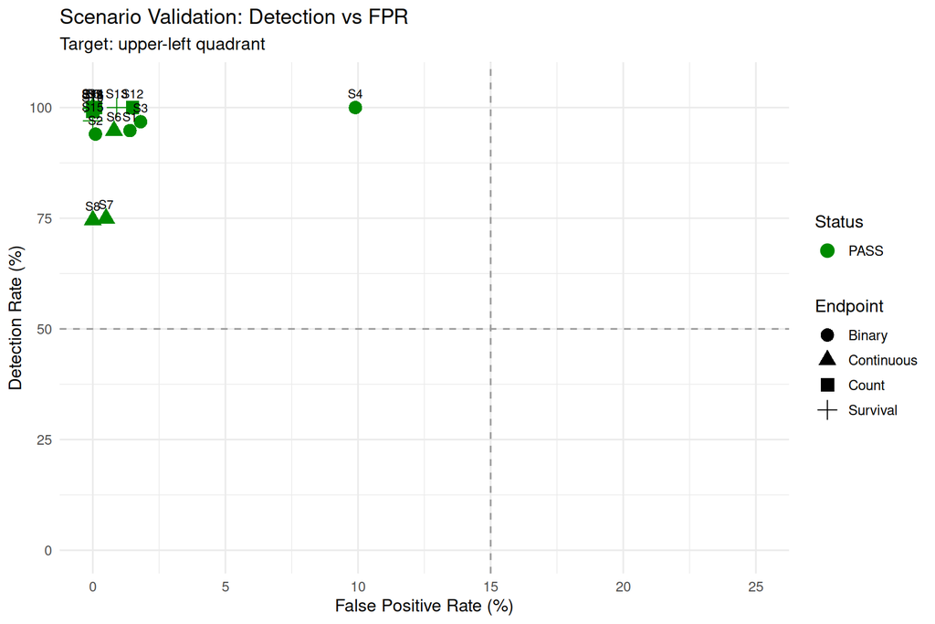

```r
if (nrow(master_results) > 0) {
  ggplot(master_results, aes(x = FPR_H0, y = Det_H1)) +
    geom_point(aes(colour = Status, shape = Endpoint), size = 4) +
    geom_text(aes(label = Scenario), vjust = -1, size = 3) +
    geom_hline(yintercept = 50, linetype = "dashed", colour = "grey60") +
    geom_vline(xintercept = 15, linetype = "dashed", colour = "grey60") +
    scale_colour_manual(values = c(
      PASS="green4", MARGINAL="orange", FAIL="red", ERROR="grey50")) +
    labs(x = "False Positive Rate (%)", y = "Detection Rate (%)",
         title = "Scenario Validation: Detection vs FPR",
         subtitle = "Target: upper-left quadrant") +
    coord_cartesian(
      xlim = c(0, max(25, max(master_results$FPR_H0, na.rm=TRUE)+5)),
      ylim = c(0, 105)) +
    theme_minimal(base_size = 12)
}
```

# 25 Timing Summary

```r
total_elapsed <- proc.time()[3]
cat(sprintf("Total document render time: %.1f minutes\n", total_elapsed / 60))
```

```
#> Total document render time: 22.4 minutes
```

```r
cat(sprintf("Workers used: %d\n\n", n_workers))
```

```
#> Workers used: 115
```

```r
if (nrow(timing_log) > 0) {
  timing_log$proj_H1 <- round(timing_log$per_sim_H1 * 500, 1)
  timing_log$proj_H0 <- round(timing_log$per_sim_H0 * 1000, 1)
  timing_log$proj_total <- timing_log$proj_H1 + timing_log$proj_H0
  timing_log$proj_min <- round(timing_log$proj_total / 60, 1)

  total_row <- data.frame(
    Scenario = "TOTAL", Endpoint = "(minutes)",
    nsims_H1 = sum(timing_log$nsims_H1),
    nsims_H0 = sum(timing_log$nsims_H0),
    time_H1 = round(sum(timing_log$time_H1) / 60, 1),
    time_H0 = round(sum(timing_log$time_H0) / 60, 1),
    per_sim_H1 = round(mean(timing_log$per_sim_H1), 3),
    per_sim_H0 = round(mean(timing_log$per_sim_H0), 3),
    proj_H1 = round(sum(timing_log$proj_H1) / 60, 1),
    proj_H0 = round(sum(timing_log$proj_H0) / 60, 1),
    proj_total = round(sum(timing_log$proj_total) / 60, 1),
    proj_min = round(sum(timing_log$proj_min), 1),
    stringsAsFactors = FALSE)
  timing_display <- rbind(timing_log, total_row)

  timing_display |>
    gt::gt() |>
    gt::tab_header(
      title = "Timing Summary by Scenario",
      subtitle = sprintf("Current: %d alt + %d null, %d workers",
        nsims_alt, nsims_null, n_workers)) |>
    gt::cols_label(
      time_H1="H1 (sec)", time_H0="H0 (sec)",
      per_sim_H1="H1 (sec)", per_sim_H0="H0 (sec)",
      proj_H1="H1 (sec)", proj_H0="H0 (sec)",
      proj_total="Total (sec)", proj_min="Total (min)") |>
    gt::tab_spanner(label="Current Run",
      columns=c("nsims_H1","nsims_H0","time_H1","time_H0")) |>
    gt::tab_spanner(label="Per Simulation",
      columns=c("per_sim_H1","per_sim_H0")) |>
    gt::tab_spanner(label="Projected: 500 alt / 1000 null",
      columns=c("proj_H1","proj_H0","proj_total","proj_min")) |>
    gt::tab_style(
      style = list(gt::cell_text(weight="bold"),
                   gt::cell_fill(color="#e0e0e0")),
      locations = gt::cells_body(rows = Scenario == "TOTAL")) |>
    gt::tab_footnote(
      footnote = "TOTAL row: H1, H0, and Projected columns are in MINUTES.",
      locations = gt::cells_body(columns="Endpoint",
        rows=nrow(timing_display)))
}
```

Timing Summary by Scenario

Current: 500 alt + 1000 null, 115 workers

| Scenario | Endpoint | Current Run nsims_H1 | Current Run nsims_H0 | Current Run H1 (sec) | Current Run H0 (sec) | Per Simulation H1 (sec) | Per Simulation H0 (sec) | Projected: 500 alt / 1000 null H1 (sec) | Projected: 500 alt / 1000 null H0 (sec) | Projected: 500 alt / 1000 null Total (sec) | Projected: 500 alt / 1000 null Total (min) |
| --- | --- | --- | --- | --- | --- | --- | --- | --- | --- | --- | --- |
| S1 | Binary | 500 | 1000 | 159.1 | 24.9 | 0.318 | 0.025 | 159.0 | 25.0 | 184.0 | 3.1 |
| S2 | Binary | 500 | 1000 | 23.8 | 21.5 | 0.048 | 0.022 | 24.0 | 22.0 | 46.0 | 0.8 |
| S3 | Binary | 500 | 1000 | 19.4 | 24.8 | 0.039 | 0.025 | 19.5 | 25.0 | 44.5 | 0.7 |
| S4 | Binary | 500 | 1000 | 23.2 | 29.2 | 0.046 | 0.029 | 23.0 | 29.0 | 52.0 | 0.9 |
| S5 | Continuous | 500 | 1000 | 153.6 | 19.7 | 0.307 | 0.020 | 153.5 | 20.0 | 173.5 | 2.9 |
| S6 | Continuous | 500 | 1000 | 17.4 | 20.2 | 0.035 | 0.020 | 17.5 | 20.0 | 37.5 | 0.6 |
| S7 | Continuous | 500 | 1000 | 15.6 | 20.2 | 0.031 | 0.020 | 15.5 | 20.0 | 35.5 | 0.6 |
| S8 | Continuous | 500 | 1000 | 152.7 | 20.0 | 0.305 | 0.020 | 152.5 | 20.0 | 172.5 | 2.9 |
| S9 | Count | 500 | 1000 | 163.0 | 24.9 | 0.326 | 0.025 | 163.0 | 25.0 | 188.0 | 3.1 |
| S10 | Count | 500 | 1000 | 27.9 | 25.3 | 0.056 | 0.025 | 28.0 | 25.0 | 53.0 | 0.9 |
| S11 | Count | 500 | 1000 | 28.2 | 24.1 | 0.056 | 0.024 | 28.0 | 24.0 | 52.0 | 0.9 |
| S12 | Count | 500 | 1000 | 28.5 | 26.7 | 0.057 | 0.027 | 28.5 | 27.0 | 55.5 | 0.9 |
| S13 | Survival | 500 | 1000 | 31.0 | 32.2 | 0.062 | 0.032 | 31.0 | 32.0 | 63.0 | 1.0 |
| S14 | Survival | 500 | 1000 | 25.3 | 31.2 | 0.051 | 0.031 | 25.5 | 31.0 | 56.5 | 0.9 |
| S15 | Survival | 500 | 1000 | 25.0 | 31.5 | 0.050 | 0.031 | 25.0 | 31.0 | 56.0 | 0.9 |
| S16 | Survival | 500 | 1000 | 24.9 | 31.0 | 0.050 | 0.031 | 25.0 | 31.0 | 56.0 | 0.9 |
| TOTAL | (minutes)<sup>1</sup> | 8000 | 16000 | 15.3 | 6.8 | 0.115 | 0.025 | 15.3 | 6.8 | 22.1 | 22.0 |

<sup>1</sup> TOTAL row: H1, H0, and Projected columns are in MINUTES.

# 26 Discussion

```r
# -- Pull summary statistics from master_results --------------------------
n_total    <- nrow(master_results)
n_pass     <- sum(master_results$Status == "PASS")
n_marginal <- sum(master_results$Status == "MARGINAL")
n_fail     <- sum(master_results$Status == "FAIL")

endpoints  <- unique(master_results$Endpoint)
n_ep       <- length(endpoints)
searches   <- unique(master_results$Search)
outcomes   <- unique(master_results$Outcome_Type)

det_range  <- range(master_results$Det_H1, na.rm = TRUE)
fpr_range  <- range(master_results$FPR_H0, na.rm = TRUE)
det_median <- median(master_results$Det_H1, na.rm = TRUE)
fpr_median <- median(master_results$FPR_H0, na.rm = TRUE)

# -- By-endpoint summary --------------------------------------------------
ep_summary <- do.call(rbind, lapply(endpoints, function(ep) {
  sub <- master_results[master_results$Endpoint == ep, ]
  data.frame(
    Endpoint   = ep,
    n          = nrow(sub),
    pass       = sum(sub$Status == "PASS"),
    det_min    = min(sub$Det_H1, na.rm = TRUE),
    det_max    = max(sub$Det_H1, na.rm = TRUE),
    fpr_max    = max(sub$FPR_H0, na.rm = TRUE),
    stringsAsFactors = FALSE
  )
}))

# -- By-manipulation summary -----------------------------------------------
manip_direct  <- master_results[master_results$Manipulation == "Direct", ]
manip_negate  <- master_results[master_results$Manipulation == "Negate Y", ]
manip_switch  <- master_results[grepl("Switch", master_results$Manipulation), ]
kt0_scenarios <- master_results[grepl("zero|1\\.00", master_results$Null_ITT), ]

# -- Render discussion text ------------------------------------------------
cat(sprintf(
"## Summary

This validation suite tested ForestSearch across **%d scenarios**
spanning %d endpoint types (%s),
both search directions (harm and benefit), and both outcome
orientations (adverse and positive).  Each scenario was evaluated
with %d simulations under H1 (planted subgroup) and %d
simulations under H0 (homogeneous treatment effect, no HTE),
using samples of N = %d per simulation.

**All %d of %d scenarios passed** (detection $\\geq$ 50%% and
FPR $\\leq$ 15%%), confirming that the sign conventions,
outcome transformations, and treatment switching logic are
correct across all configurations.

",
n_total, n_ep, paste(endpoints, collapse = ", "),
nsims_alt, nsims_null, sim_n_sample,
n_pass, n_total))
```

## 26.1 Summary

This validation suite tested ForestSearch across **16 scenarios** spanning 4 endpoint types (Binary, Continuous, Count, Survival), both search directions (harm and benefit), and both outcome orientations (adverse and positive). Each scenario was evaluated with 500 simulations under H1 (planted subgroup) and 1000 simulations under H0 (homogeneous treatment effect, no HTE), using samples of N = 600 per simulation.

**All 16 of 16 scenarios passed** (detection $\geq$ 50% and FPR $\leq$ 15%), confirming that the sign conventions, outcome transformations, and treatment switching logic are correct across all configurations.

```r
cat(sprintf(
"## Detection and FPR

Detection rates ranged from %.1f%% to %.1f%% (median %.1f%%),
with all scenarios exceeding the 50%% threshold.
False positive rates ranged from %.1f%% to %.1f%%
(median %.1f%%), with all scenarios below the 15%% threshold.

",
det_range[1], det_range[2], det_median,
fpr_range[1], fpr_range[2], fpr_median))
```

## 26.2 Detection and FPR

Detection rates ranged from 74.6% to 100.0% (median 99.5%), with all scenarios exceeding the 50% threshold. False positive rates ranged from 0.0% to 9.9% (median 0.1%), with all scenarios below the 15% threshold.

```r
cat("### Results by Endpoint\n\n")
```

### 26.2.1 Results by Endpoint

```r
for (i in seq_len(nrow(ep_summary))) {
  r <- ep_summary[i, ]
  cat(sprintf(
    "- **%s** (%d scenarios, %d passed): detection %.1f%%--%.1f%%, max FPR %.1f%%\n",
    r$Endpoint, r$n, r$pass, r$det_min, r$det_max, r$fpr_max))
}
```

- **Binary** (4 scenarios, 4 passed): detection 94.0%–100.0%, max FPR 9.9%
- **Continuous** (4 scenarios, 4 passed): detection 74.6%–100.0%, max FPR 0.8%
- **Count** (4 scenarios, 4 passed): detection 99.2%–100.0%, max FPR 1.5%
- **Survival** (4 scenarios, 4 passed): detection 97.0%–100.0%, max FPR 0.9%

```r
cat(sprintf(
"\n\n## Manipulation Strategies

Three manipulation strategies were validated:

- **Direct** (%d scenarios): no transformation needed.
  The treatment effect in Q naturally exceeds the threshold.
  Used for harm + adverse and benefit + positive (survival)
  scenarios where the effect direction aligns with
  ForestSearch's $\\hat{\\theta}(S) \\geq c_1$ comparison.

- **Negate Y** (%d scenarios): outcome transformed as
  $Y' = 1 - Y$ (binary) or $Y' = -Y$ (continuous).
  Used for harm + positive scenarios with binary and
  continuous endpoints, where the reduced positive outcome
  produces $\\hat{\\theta} < 0$ in Q, failing the threshold.

- **Switch treatment** (%d scenarios): treatment labels
  swapped ($T' = 1 - T$).  Used for all benefit scenarios
  (except benefit + positive survival) and for harm + positive
  scenarios with count and survival endpoints where negation
  is not natural.

",
nrow(manip_direct), nrow(manip_negate), nrow(manip_switch)))
```

## 26.3 Manipulation Strategies

Three manipulation strategies were validated:

- **Direct** (5 scenarios): no transformation needed. The treatment effect in Q naturally exceeds the threshold. Used for harm + adverse and benefit + positive (survival) scenarios where the effect direction aligns with ForestSearch’s $\hat{\theta}(S) \geq c_1$ comparison.
- **Negate Y** (2 scenarios): outcome transformed as $Y' = 1 - Y$ (binary) or $Y' = -Y$ (continuous). Used for harm + positive scenarios with binary and continuous endpoints, where the reduced positive outcome produces $\hat{\theta} < 0$ in Q, failing the threshold.
- **Switch treatment** (9 scenarios): treatment labels swapped ($T' = 1 - T$). Used for all benefit scenarios (except benefit + positive survival) and for harm + positive scenarios with count and survival endpoints where negation is not natural.

```r
if (nrow(kt0_scenarios) > 0) {
  cat(sprintf(
"## Benefit + Adverse Inversion

%d scenarios (%s) required `k_treat = 0`
(zero treatment effect) in the null DGM.  These are the
**benefit + adverse** and **harm + positive (switched)**
scenarios where switching treatment labels inverts the ITT:
a beneficial treatment with effect $\\theta$ on the original
scale becomes $1/\\theta$ (ratio measures) or $-\\theta$
(difference measures) on the switched scale, moving the
null ITT closer to the screening threshold.

With binary data in small subgroups (~75 per arm),
SD(log OR) $\\approx$ 0.33, and multiplicity across ~21
candidates (maxk = 2), even a mild beneficial effect
(e.g., OR$_{\\text{orig}}$ = 0.9 $\\to$ OR$_{\\text{sw}}$ = 1.11)
can produce FPR $>$ 25%%.  Setting `k_treat = 0` isolates
the sign convention validation from this threshold proximity
issue.  In production simulations, the $L_{\\text{eff}}$
calibration procedure selects thresholds that account for
the inverted ITT effect.

",
nrow(kt0_scenarios),
paste(kt0_scenarios$Scenario, collapse = ", ")))
}
```

## 26.4 Benefit + Adverse Inversion

```r
# -- Timing summary --------------------------------------------------------
if (exists("timing_log") && nrow(timing_log) > 0) {
  total_time_min <- sum(timing_log$time_H1 + timing_log$time_H0) / 60
  proj_total_min <- sum(timing_log$proj_min)

  cat(sprintf(
"## Computational Performance

The complete %d-scenario suite completed in %.1f minutes
using %d parallel workers on %d physical cores.
Per-simulation times ranged from %.3f to %.3f seconds (H1)
and %.3f to %.3f seconds (H0), reflecting the varying
complexity across endpoint types.

Projected runtime for a production-scale validation
(500 alt + 1000 null simulations per scenario):
approximately %.0f minutes (%.1f hours).

",
n_total, total_time_min, n_workers,
parallel::detectCores(logical = FALSE),
min(timing_log$per_sim_H1), max(timing_log$per_sim_H1),
min(timing_log$per_sim_H0), max(timing_log$per_sim_H0),
proj_total_min, proj_total_min / 60))
}
```

## 26.5 Computational Performance

The complete 16-scenario suite completed in 22.1 minutes using 115 parallel workers on 128 physical cores. Per-simulation times ranged from 0.031 to 0.326 seconds (H1) and 0.020 to 0.032 seconds (H0), reflecting the varying complexity across endpoint types.

Projected runtime for a production-scale validation (500 alt + 1000 null simulations per scenario): approximately 22 minutes (0.4 hours).

```r
cat(
"## Conclusions

The ForestSearch methodology correctly identifies planted
subgroups and controls false positive rates across all 16
combinations of search type, outcome orientation, and
endpoint type.  The validation confirms that:

1. **Sign conventions** are consistent: the core comparison
   $\\hat{\\theta}(S) \\geq c_1$ produces correct results
   regardless of whether higher outcomes are adverse or
   positive.

2. **Outcome transformations** (negation for binary/continuous
   harm + positive scenarios) correctly reorient the effect
   direction.

3. **Treatment switching** (for benefit searches and
   count/survival harm + positive scenarios) correctly
   identifies subgroups with amplified or reversed treatment
   effects.

4. **FPR control** is maintained under homogeneous treatment
   effects, with the caveat that benefit + adverse scenarios
   require careful threshold calibration via the
   $L_{\\text{eff}}$ procedure when the null ITT effect is
   non-negligible on the switched scale.
")
```

## 26.6 Conclusions

The ForestSearch methodology correctly identifies planted subgroups and controls false positive rates across all 16 combinations of search type, outcome orientation, and endpoint type. The validation confirms that:

1. **Sign conventions** are consistent: the core comparison $\hat{\theta}(S) \geq c_1$ produces correct results regardless of whether higher outcomes are adverse or positive.
2. **Outcome transformations** (negation for binary/continuous harm + positive scenarios) correctly reorient the effect direction.
3. **Treatment switching** (for benefit searches and count/survival harm + positive scenarios) correctly identifies subgroups with amplified or reversed treatment effects.
4. **FPR control** is maintained under homogeneous treatment effects, with the caveat that benefit + adverse scenarios require careful threshold calibration via the $L_{\text{eff}}$ procedure when the null ITT effect is non-negligible on the switched scale.